# retailsales_a1

**Example Analysis of Retail Sales**

This document summarises some R code and analysis to revise the analysis of the retail sales time series from the first three weeks of semester, with particular reference to preparing to do Assignment 1. The following provides a review of:

- reading in and setting up the data
- how to use observation indices to reference sample and forecast periods
- regression estimation of a linear trend model
- regression estimation of a linear trend with break at an unknown time
- AR lag length selection
- recursive one-step-ahead forecasting

**Data set up**

The usual data set up for a quarterly time series of total retail sales between March quarter 2000 and December quarter 2019. The last four quarters (2019q1-4) are reserved for forecast evaluation.

```r
library(forecast)
dtm <- read.csv("RetailSales.csv")

# Create quarterly retail sales time series
Retail_q <- aggregate(ts(dtm$Total,
                         start = c(1982, 4),
                         end = c(2024, 9),
                         frequency = 12),
                      nfrequency = 4)

# Restrict sample to 2000q1 to 2019q4
Y <- window(log(Retail_q),
            start = c(2000, 1),
            end = c(2019, 4))
Time <- time(Y)
QD <- seasonaldummy(Y)
```

**Observation indices**

We will use R variables `ts` and `tf` for the observation indices for the estimation sample period and forecast evaluation period respectively. The forecast period is defined as follows:

```r
# Observation indices for the forecast period
tf <- which(Time > 2018.75)
```

```
  tf : 77 78 79 80
```

That is we have a total of 80 observations from 2000q1 to 2019q4, with the last four observations (77, 78, 79, 80) for 2019q1–q4 being used for the forecast evaluation period. As a reminder of the structure of `Time` obtained from the `time()` command, here are the values of `Time` associated with the forecast evaluation period:

```r
print(Time[tf])
```

```
[1] 2019.00 2019.25 2019.50 2019.75
```

Recall the first quarter is denoted `.00`, the second quarter `.25`, the third quarter `.50` and the fourth quarter `.75`, which may be unintuitive at first sight.

The time indices for the estimation sample can be defined similarly:

```r
# Observation indices for the estimation sample
ts <- which(Time <= 2018.75)
```

Thus `Y[ts]` references the 76 values of `Y` to be used for model specification and estimation, which is equivalent to `window(Y, end = c(2018, 4))`. Similarly the 4 values of `Y` for forecast evaluation are `Y[tf]`, which is equivalent to `window(Y, start = c(2019, 1))`:

```r
print(Y[tf])
```

```
[1] 11.25749 11.27666 11.29348 11.43911
```

```r
print(window(Y, start = c(2019, 1)))
```

```
         Qtr1     Qtr2     Qtr3     Qtr4
2019 11.25749 11.27666 11.29348 11.43911
```

Just notice that `window(Y, start = c(2019, 1))` remains a `ts()` object and hence retains the time series dates `2019 Qtr 1` etc, while `Y[ts]` is simply a numeric vector without the time series dates attached.

**Linear trend function**

First we review the estimation of a linear trend for `Y` using `lm()`. It is convenient to create a dataframe containing the data and associated variables.

```r
dt <- data.frame(Time = Time,
                 QD1 = QD[, 1],
                 QD2 = QD[, 2],
                 QD3 = QD[, 3],
                 Y = Y)
```

The first two years of data in the dataframe appear as follows.

```
     Time QD1 QD2 QD3        Y
1 2000.00   1   0   0 10.36845
2 2000.25   0   1   0 10.41445
3 2000.50   0   0   1 10.41161
4 2000.75   0   0   0 10.58049
5 2001.00   1   0   0 10.43933
6 2001.25   0   1   0 10.47452
7 2001.50   0   0   1 10.49662
8 2001.75   0   0   0 10.66664
```

Note `QD1`, `QD2`, `QD3` correspond to quarters 1, 2 and 3 respectively, and there is no need for a fourth quarterly dummy for quarter 4.

A regression on linear trend and seasonal dummies is obtained for the estimation sample as follows:

```r
eq0 <- lm(Y ~ QD1 + QD2 + QD3 + Time, data = dt[ts, ])
```

(Note use of `[ts, ]` in `data = dt[ts, ]` for the estimation sample.)

Here is a time series plot of the data in the estimation sample and the fitted trend regression (using points because that is clearer when superimposing a regression line):

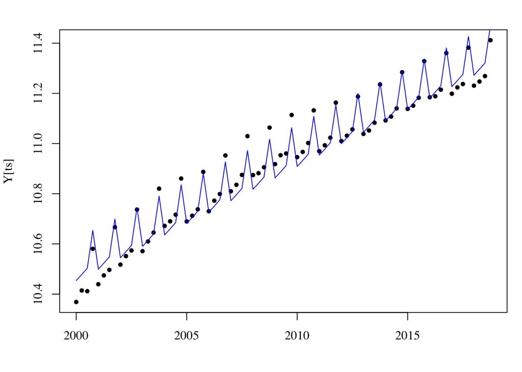

```r
plot(Time[ts], Y[ts], pch = 16, cex = 0.8)
lines(Time[ts], eq0$fitted, col = "blue")
```

The estimated trend model has coefficients:

```
            Estimate Std. Error t value  Pr(>|t|)
(Intercept) -80.2876   1.5566   -51.5796   0.0000
QD1          -0.1658   0.0120   -13.8050   0.0000
QD2          -0.1531   0.0120   -12.7511   0.0000
QD3          -0.1395   0.0120   -11.6267   0.0000
Time          0.0455   0.0008    58.6878   0.0000
```

and can be written in equation form as
$$Y_t = -80.288
-0.166 \: \text{QD1}_t
-0.153 \: \text{QD2}_t
-0.140 \: \text{QD3}_t
+0.045 \: \text{Time}_t
+ \widehat{Z}_t$$

**Linear trend with estimated break time**

Instead of assuming we know the date at which to include a trend break for the GFC, we can search for the “best” date, with “best” defined as usual by least squares. That is, the trend equation is
$$Y_t = \beta_0
+ \beta_1 \text{QD}_{1,t}
+ \beta_2 \text{QD}_{2,t}
+ \beta_3 \text{QD}_{3,t}
+ \beta_4 \text{Time}_t
+ \beta_5 \text{TB}_t(b)
+ Z_t$$
where $\text{TB}_t(b)$ is the trend break variable
$$\text{TB}_t(b) = 1(\text{Time}_t > b) \times (\text{Time}_t - b)$$
with break at time $b$. For each $b$ in a specified range of break dates the corresponding regression coefficients $\beta_0, \ldots, \beta_5$ can be estimated in the usual way, along with the residual sum of squares for each break date, $\text{RSS}(b)$. Then the value of $b$ that minimises $\text{RSS}(b)$ is the “best”.

We will allow the GFC break date to be estimated within the period 2007q3 (`2007.5`) to 2009q2 (`2009.25`):

```r
Break_range <- Time[which(Time >= 2007.5 & Time <= 2009.25)]
```

```
  Break_range : 2007.5 2007.75 2008 2008.25 2008.5 2008.75 2009 2009.25
```

```r
# M is a matrix for the RSS corresponding to each b
M <- matrix(nrow = length(Break_range), ncol = 2)
colnames(M) <- c("b", "RSS")
M[, "b"] <- Break_range

# Estimate trend and obtain RSS for each b in the range:
for (b in Break_range){

  # Trend break variable at b
  dt$TB_b <- (dt$Time > b) * (dt$Time - b)

  # OLS estimation of trend equation with break
  eq1 <- lm(Y ~ QD1 + QD2 + QD3 + Time + TB_b, data = dt[ts, ])

  # Store RSS in appropriate entry of M
  M[which(M[, "b"] == b), "RSS"] <- sum(eq1$residuals^2)

}
```

The content of `M` is:

```
         b     RSS
   2007.50 0.01472
   2007.75 0.01452
   2008.00 0.01471
   2008.25 0.01524
   2008.50 0.01591
   2008.75 0.01670
   2009.00 0.01769
   2009.25 0.01898
```

The idea is to choose the value of $b$ corresponding to the smallest RSS:

```r
# which.min(M[, "RSS"]) ; the row of M minimising "RSS"
# M[which.min(M[, "RSS"]), "b"] : the corresponding b
b <- M[which.min(M[, "RSS"]), "b"]
```

```
  b = 2007.75
```

i.e. the break date is estimated to be 2007q4. The chosen trend break regression can then be estimated as follows.

```r
# Define TB_b for the estimated b
dt$TB_b <- (dt$Time > b) * (dt$Time - b)

# Estimate equation with trend break
eq1 <- lm(Y ~ QD1 + QD2 + QD3 + Time + TB_b, data = dt[ts, ])
```

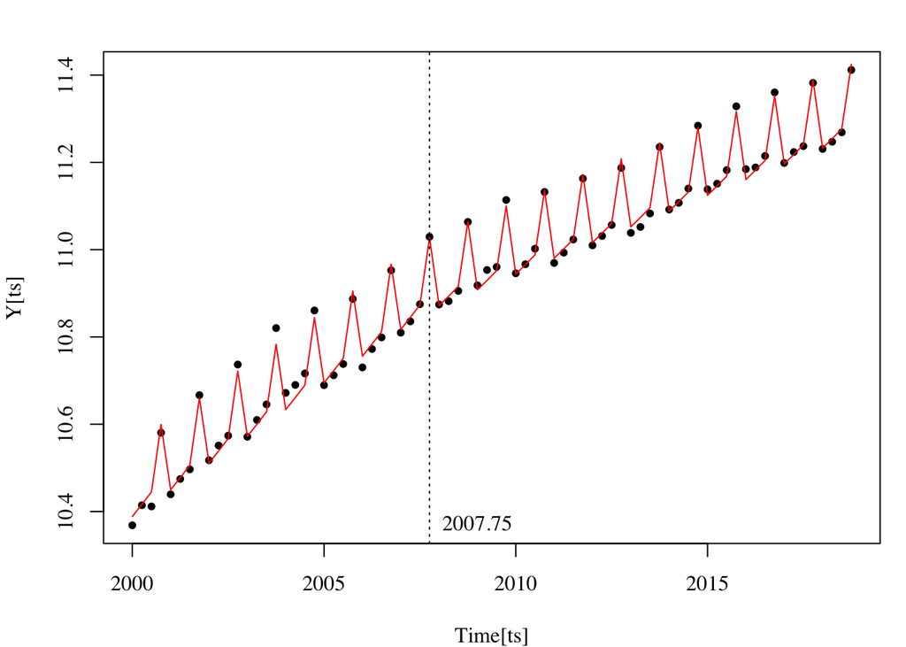

```r
plot(Time[ts], Y[ts], pch = 16, cex = 0.8)
lines(Time[ts], eq1$fitted, col = "red")
abline(v = b, lty = 3)
```

The estimated trend model has coefficients:

```
            Estimate  Std. Error t value   Pr(>|t|)
(Intercept) -111.8796    1.6954   -65.9898    0.0000
QD1           -0.1649    0.0047   -35.2514    0.0000
QD2           -0.1525    0.0047   -32.6111    0.0000
QD3           -0.1392    0.0047   -29.7892    0.0000
Time           0.0612    0.0008    72.3922    0.0000
TB_b          -0.0251    0.0013   -19.9530    0.0000
```

and can be written in equation form as
$$\begin{aligned}
Y_t = -111.880
& -0.165 \: \text{QD1}_t
-0.152 \: \text{QD2}_t
-0.139 \: \text{QD3}_t
\\
& +0.061 \: \text{Time}_t
-0.025 \: \text{TB}_t(\widehat{b})
+ \widehat{Z}_t
\end{aligned}$$
where $\widehat{b} = 2007.75$.

**AR lag length selection: linear trend + QDs**

```r
# Regressor matrix: seasonal dummies + trend
X0 <- as.matrix(dt[, c("QD1", "QD2", "QD3", "Time")])

# Max lag length
pmax <- 8

# Storage for AICc and Ljung-Box p-values
Stats <- matrix(nrow = pmax + 1, ncol = 3)
colnames(Stats) <- c("p", "AICc", "LBp")

for (p in 0:pmax){

  # AR(p) estimation with X0 as xreg
  ARp <- Arima(Y[ts],
               order = c(p, 0, 0),
               xreg = X0[ts, ])

  # Ljung-Box autocorrelation test p-value
  LBp <- Box.test(ARp$residuals, lag = 12,
                  type = "Ljung-Box",
                  fitdf = p)$p.value

  # Store lag length, AICc, Ljung-Box p-value
  Stats[p + 1, ] <- c(p, ARp$aicc, LBp)

}
```

The content of `Stats` is as follows.

```
   p    AICc   LBp
   0 -277.47 0.000
   1 -457.00 0.002
   2 -456.33 0.044
   3 -459.66 0.530
   4 -457.02 0.429
   5 -456.85 0.647
   6 -454.54 0.538
   7 -452.67 0.255
   8 -449.98 0.204
```

The approach is to choose the value of `p` that minimises the AICc. It’s also important to check the residual autocorrelation test of the chosen model, in this case the Ljung-Box *p*-value.

```r
# Row of Stats with minimum AICc
r <- which.min(Stats[, "AICc"])

# Lag length p that minimises AICc
p0 <- Stats[r, "p"]

# Ljung-Box p-value for chosen lag length
LBp0 <- Stats[r, "LBp"]
```

```
  AR lag length =  3 , LBp =  0.530
```

The lag length $p=3$ selected by the AICc produces an AR(3) model with residuals that pass the Ljung-Box autocorrelation test, hence this is the selected model with linear trend.

**AR lag length selection: linear trend with break**

```r
# Regressor matrix: seasonal dummies + trend + trend break
X1 <- as.matrix(dt[, c("QD1", "QD2", "QD3", "Time", "TB_b")])

# Max lag length
pmax <- 8

# Storage for AICc and Ljung-Box p-values
Stats <- matrix(nrow = pmax + 1, ncol = 3)
colnames(Stats) <- c("p", "AICc", "LBp")

for (p in 0:pmax){

  # AR(p) estimation with X1 as xreg
  ARp <- Arima(Y[ts],
               order = c(p, 0, 0),
               xreg = X1[ts, ])

  # Ljung-Box autocorrelation test p-value
  LBp <- Box.test(ARp$residuals, lag = 12,
                  type = "Ljung-Box",
                  fitdf = p)$p.value

  # Store lag length, AICc, Ljung-Box p-value
  Stats[p + 1, ] <- c(p, ARp$aicc, LBp)

}

# Row of Stats with minimum AICc
r <- which.min(Stats[, "AICc"])

# Lag length p that minimises AICc
p1 <- Stats[r, "p"]

# Ljung-Box p-value for chosen lag length
LBp1 <- Stats[r, "LBp"]
```

```
  AR lag length =  3 , LBp =  0.444
```

Again an AR(3) model is chosen, and passes the Ljung-Box test.

**Recursive one-step-ahead forecasting**

The following shows a loop to carry out a recursive one-step-ahead forecasting exercise to compare the performance of the AR models with trend and trend+break in forecasting the four quarters of 2019. (The break location and AR lag length will not be reselected with each estimation, although that could be done with a little more complication.)

To be specific:

1. Estimate both models for the estimation sample 2000q1 to 2018q4 (i.e. $t=1,\ldots,n$ with $n = 76$), and from each model forecast the observation for 2019q1 (i.e. $t = n+1 = 77$).
2. Estimate both models for the estimation sample 2000q1 to 2019q1 (i.e. $t=1,\ldots,n$ with $n = 77$), and from each model forecast the observation for 2019q2 (i.e. $t = n+1 = 78$).
3. Estimate both models for the estimation sample 2000q1 to 2019q2 (i.e. $t=1,\ldots,n$ with $n = 78$), and from each model forecast the observation for 2019q3 (i.e. $t = n+1 = 79$).
4. Estimate both models for the estimation sample 2000q1 to 2019q3 (i.e. $t=1,\ldots,n$ with $n = 79$), and from each model forecast the observation for 2019q4 (i.e. $t = n+1 = 80$).

In summary, we estimate the models with $n=76, 77, 78, 79$ and respectively compute one-step-ahead forecasts for times $t = n{\color{red}{\:+ \: 1}} = 77, 78, 79, 80$. The actual observations for those four time periods are available to compute forecast errors and hence RMSE for forecast evaluation.

```r
# Empty time series to contain forecasts
ARp_f1 <- ts(start = c(2000, 1), end = c(2019, 4), frequency = 4)
ARp_TB_f1 <- ts(start = c(2000, 1), end = c(2019, 4), frequency = 4)

# Increase sample size n one at a time through the forecast period
#   tf = (77, 78, 79, 80)
#   tf - 1 = (76, 77, 78, 79)
# The recursive values for n are hence in tf - 1.

for (n in (tf - 1)){

  t <- 1:n

  ARp <- Arima(Y[t],
               order = c(p0, 0, 0),
               xreg = X0[t, ])
  ARp_f1[n + 1] <- forecast(ARp, xreg = X0[n + 1, , drop = FALSE])$mean

  ARp_TB <- Arima(Y[t],
                  order = c(p1, 0, 0),
                  xreg = X1[t, ])
  ARp_TB_f1[n + 1] <- forecast(ARp_TB, xreg = X1[n + 1, , drop = FALSE])$mean

}

Forecasts <- cbind(ARp_f1[tf], ARp_TB_f1[tf])
```

The resulting sequence of one-step-ahead forecasts from the two models are tabulated here:

```
          ARp_f1 ARp_TB_f1
2019    11.25921  11.25878
2019.25 11.28027  11.27947
2019.5  11.30287  11.30203
2019.75 11.44525  11.44529
```

The forecast errors and RMSE are computed as follows.

```r
ForecastErrors <- Y[tf] - Forecasts
RMSE <- round(sqrt(apply(ForecastErrors^2, 2, mean)), 4)
```

```
      ARp_f1 ARp_TB_f1
RMSE:  0.006    0.0055
```

According to the RMSE comparison the forecasts from the AR(3) model with trend break are slightly more accurate than those from the AR(3) model without trend break. The difference is minor though, the forecasts from the two models are essentially the same for any practical purpose, as can be seen in the plot below.

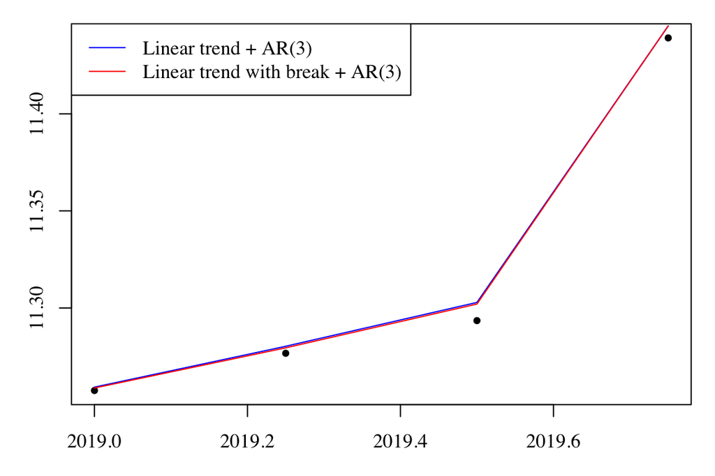